# Wrangle Report

## Introduction

This is a data wrangling project involving the WeRateDogs twitter archive (@dog_rates). The project requires 3 different datasets:

- "twitter_archive_enhanced.csv" which was provided as a downloadable csv file.
- "image_predictions.tsv" which i had to download programatically using request library.
- tweet_json.txt which i had to get using the provided support materials rather than scraping it from twitter's server. This is because twitter did not aprove my request for a developer account. The goal was to gather these data in different formats, clean them and analyze them to draw insights.

## About the Datasets

As stated above, the data was made available in three sets: **twitter-archive-enhanced.csv**: This was obtained directly from the twitter account administrator. It contains tweet id for tweets made up until August 1st, 2017. There are other important columns in the table including tweet text, source, retweeted_status_id, among others. This is the core file for this project.

**image_predictions.tsv**: A tab separated file containing the tweet id, and tweet image information. These images were passed through a neural network to filter out non-dog images.

**tweet_json.txt**: This contains extra data from the WeRateDogs tweets. It includes tweet id, favorite count, retweet count, among other columns.

## Assessing The Datasets

The datasets were loaded to a pandas dataframe one by one. Afterwards, I performed visual and programmatic assessments on them using relevant python functions (e.g .head(), .describe(), .sample() e.t.c) to identify quality and tidiness issues.

### Notable Issues Observed

#### Quality issues:

1. For better analysis, timestamp and retweeted_status_timestamp columns should be in datetime format instead of string.
2. The column, text, includes url
3. Some columns are in the wrong datatype
4. According the img prediction algorithm, Not all are dogs
5. dog stage columns are in wrong datatype
6. wrongly extracted rating values at index 1165
7. Some rows contain invalid names (lower case alphabets, etc)
8. Some rows contain retweets instead of original post.

#### Tidiness Issues

1. The dog stage names formed their own columns
2. The three datasets contain related information but form different tables

### Cleaning the Dataset

Cleaning is definitely one of the most challenging steps in the data analysis process. The notable issues listed above were cleaned one by one to prepare, and produce a final high quality data. I started the cleaning process by makining copies of the initial data sets, just as learned in the classroom. then i proceed to tackling the first issue which was relatively straightforward and simple. In addition to other procedural programming efforts using pandas and python functions, Some helpful functions were defined and used to help clean the tables. A good example is the lamda function used to remove url in the "text" column (Issue 2). The for loop keyword was also used a couple of times to deal recurent issuess, and run them once (It's a very impressive keyword to use). In the end, data were meged and exported to a csv file as a master data (master_cleaned) before proceeding to visualization.

### Analysis & Visualization

The following questions were analysed:

- **What is the distribution of the dog stages?**
- **Which dog stage tends to get higher ratings?**
- **Does Favorite count (Likes) correlate with Retweets?**

### Results

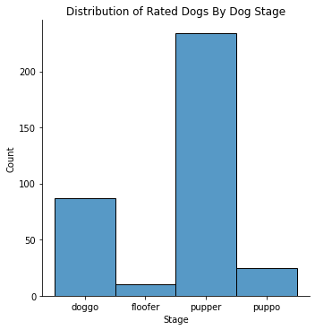

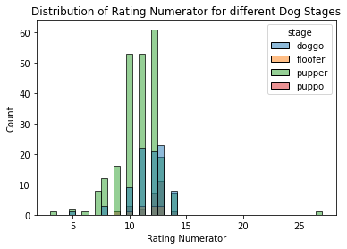

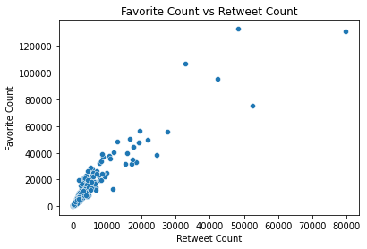

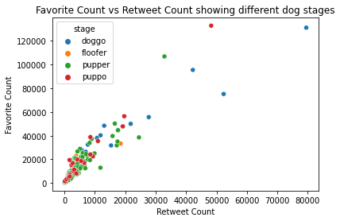